title: "Anomaly Detection in Bank Transactions" author: "Darwhin Gomez" date: "12-13-2024" output: html_document: theme: united highlight: tango toc: true toc_depth: 3 toc_float: true css: styles.css

```python
import pandas as pd
import numpy as np
from sklearn.ensemble import IsolationForest
from sklearn.preprocessing import LabelEncoder, StandardScaler
import matplotlib.pyplot as plt
import seaborn as sns
```

# Fraud Detection in Bank Transactions

## Abstract

This project focuses on detecting anomalies in bank transactions using the Isolation Forest algorithm. The dataset comprises various features such as transaction amount, account balance, login attempts, transaction type, and location. The data was preprocessed by encoding categorical features, standardizing numerical features, and extracting date-related attributes. Exploratory Data Analysis (EDA) revealed patterns in transaction amounts, login attempts, and account balances. The Isolation Forest model, with a contamination threshold of 1%, flagged 26 transactions as anomalies. SHAP (SHapley Additive exPlanations) was used to interpret the model's decisions, highlighting features such as login attempts, transaction amount, and transaction type as key indicators. The findings suggest that anomalies are characterized by higher transaction amounts, more login attempts, and higher account balances, which can be indicative of potential fraudulent activities.

## Introduduction

Fraud detection remains a critical challenge in the financial industry. As fraudulent activities can involve abnormal transaction behaviors, detecting outliers or anomalies in large transaction datasets is key to identifying potential fraud. This project uses unsupervised learning techniques such as **anomaly detection** to flag suspicious transactions based on transaction data.

Research Question: How can anomalies in bank transactions be detected using unsupervised machine learning specifically Isolation Forrest, and what features contribut the most to identifying these anomalies?

Objective: The objective of this project is to detect anomalies in bank transactions using the Isolation Forest algorithm. Bank transactions can exhibit suspicious patterns indicative of fraud, such as high transaction amounts, repeated login attempts, and unusual transaction times. This analysis uses a dataset containing transaction details, customer information, and contextual data (e.g., location and transaction type). The goal is to identify outliers and understand the key factors influencing the model's anomaly detection.

## Loading the Data

```python
# Load the dataset
df = pd.read_csv('bank_transactions_data_2.csv')

# Inspect the first few rows
print(df.head(5))
df.info()
```

```
  TransactionID AccountID  TransactionAmount      TransactionDate  \
0      TX000001   AC00128              14.09  2023-04-11 16:29:14
1      TX000002   AC00455             376.24  2023-06-27 16:44:19
2      TX000003   AC00019             126.29  2023-07-10 18:16:08
3      TX000004   AC00070             184.50  2023-05-05 16:32:11
4      TX000005   AC00411              13.45  2023-10-16 17:51:24

  TransactionType   Location DeviceID      IP Address MerchantID Channel  \
0           Debit  San Diego  D000380  162.198.218.92       M015     ATM
1           Debit    Houston  D000051     13.149.61.4       M052     ATM
2           Debit       Mesa  D000235  215.97.143.157       M009  Online
3           Debit    Raleigh  D000187  200.13.225.150       M002  Online
4          Credit    Atlanta  D000308    65.164.3.100       M091  Online

   CustomerAge CustomerOccupation  TransactionDuration  LoginAttempts  \
```

[output cut: 35 more lines]

# EDA

Exploring the dataset and making some visualzations

We can start with just viewing some summary statistics of our dataset.

```python
df.describe()
```

|  | TransactionAmount | CustomerAge | TransactionDuration | LoginAttempts | AccountBalance |
| --- | --- | --- | --- | --- | --- |
| count | 2512.000000 | 2512.000000 | 2512.000000 | 2512.000000 | 2512.000000 |
| mean | 297.593778 | 44.673965 | 119.643312 | 1.124602 | 5114.302966 |
| std | 291.946243 | 17.792198 | 69.963757 | 0.602662 | 3900.942499 |
| min | 0.260000 | 18.000000 | 10.000000 | 1.000000 | 101.250000 |
| 25% | 81.885000 | 27.000000 | 63.000000 | 1.000000 | 1504.370000 |
| 50% | 211.140000 | 45.000000 | 112.500000 | 1.000000 | 4735.510000 |
| 75% | 414.527500 | 59.000000 | 161.000000 | 1.000000 | 7678.820000 |
| max | 1919.110000 | 80.000000 | 300.000000 | 5.000000 | 14977.990000 |

```
Value Counts for Channel:
Channel
Branch    868
ATM       833
Online    811
Name: count, dtype: int64

Value Counts for CustomerOccupation:
CustomerOccupation
Student     657
Doctor      631
Engineer    625
Retired     599
Name: count, dtype: int64

Value Counts for Location:
Location
Fort Worth          70
Los Angeles         69
Oklahoma City       68
Charlotte           68
Tucson              67
Philadelphia        67
Omaha               65
Miami               64
Detroit             63
Houston             63
Memphis             63
Denver              62
Kansas City         61
Boston              61
Mesa                61
Atlanta             61
Seattle             61
Colorado Springs    60
Jacksonville        60
Fresno              60
Chicago             60
Austin              59
San Jose            59
```

[output cut: 12 more lines]

```
Sacramento          53
Baltimore           51
Louisville          51
Dallas              49
Washington          48
El Paso             46
Portland            42
Albuquerque         41
Name: count, dtype: int64

Value Counts for TransactionType:
TransactionType
Debit     1944
Credit     568
Name: count, dtype: int64
```

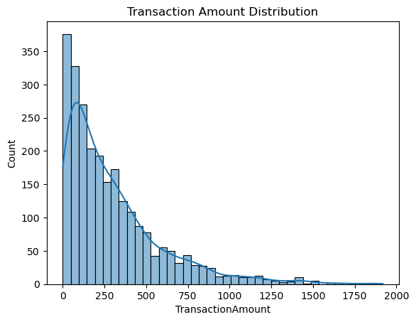

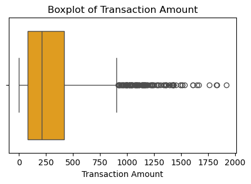

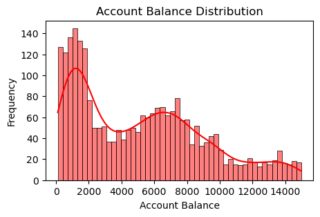

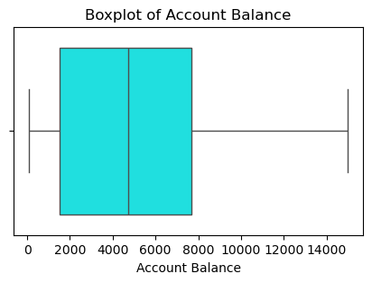

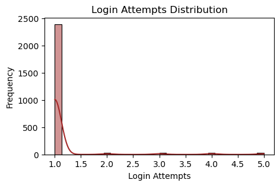

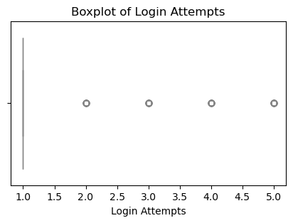

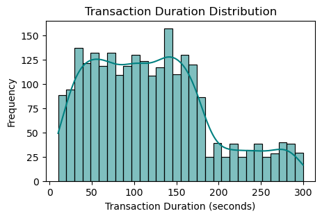

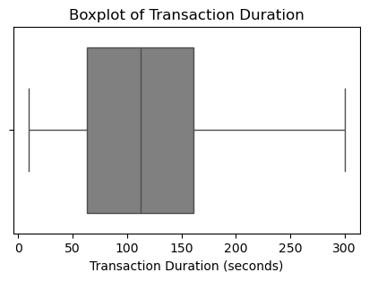

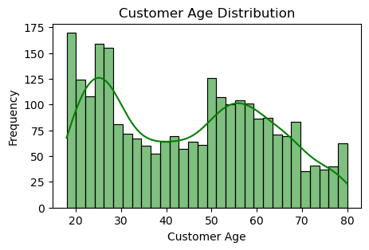

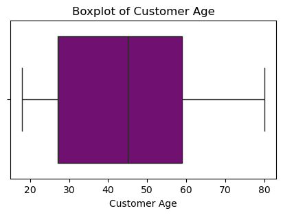

```python
excluded_cols = ['IP Address','TransactionID', 'AccountID', 'MerchantID', 'TransactionDate', 'DeviceID', 'PreviousTransactionDate']
bank_trans_data = df
# Select categorical columns, excluding the identifier-like columns
categorical_cols = bank_trans_data.select_dtypes(include=['object']).columns.difference(excluded_cols)

# Display value counts for each remaining categorical column
for col in categorical_cols:
    print(f"\nValue Counts for {col}:")
    print(bank_trans_data[col].value_counts())



# Initial Visualization of Transaction Amount Distribution
sns.histplot(bank_trans_data['TransactionAmount'], kde=True)
plt.title('Transaction Amount Distribution')
plt.show()


# Boxplot to detect outliers in Transaction Amount
plt.figure(figsize=(5, 3))
sns.boxplot(x=bank_trans_data['TransactionAmount'], color='orange')
plt.title('Boxplot of Transaction Amount')
plt.xlabel('Transaction Amount')
plt.show()
#  **Account Balance**
plt.figure(figsize=(5, 3))
sns.histplot(bank_trans_data['AccountBalance'], kde=True, color='red', bins=50)
plt.title('Account Balance Distribution')
plt.xlabel('Account Balance')
plt.ylabel('Frequency')
plt.show()


# Boxplot for Account Balance
plt.figure(figsize=(5, 3))
sns.boxplot(x=bank_trans_data['AccountBalance'], color='cyan')
plt.title('Boxplot of Account Balance')
plt.xlabel('Account Balance')
plt.show()


# 5. **Login Attempts**
plt.figure(figsize=(5, 3))
sns.histplot(bank_trans_data['LoginAttempts'], kde=True, color='brown', bins=30)
plt.title('Login Attempts Distribution')
plt.xlabel('Login Attempts')
plt.ylabel('Frequency')
plt.show()

# Boxplot for Login Attempts
plt.figure(figsize=(5, 3))
sns.boxplot(x=bank_trans_data['LoginAttempts'], color='pink')
plt.title('Boxplot of Login Attempts')
plt.xlabel('Login Attempts')
plt.show()


# 6. **Transaction Duration**
plt.figure(figsize=(5, 3))
sns.histplot(bank_trans_data['TransactionDuration'], kde=True, color='teal', bins=30)
plt.title('Transaction Duration Distribution')
plt.xlabel('Transaction Duration (seconds)')
plt.ylabel('Frequency')
plt.show()


# Boxplot for Transaction Duration
plt.figure(figsize=(5, 3))
sns.boxplot(x=bank_trans_data['TransactionDuration'], color='grey')
plt.title('Boxplot of Transaction Duration')
plt.xlabel('Transaction Duration (seconds)')
plt.show()
# 3. **Customer Age**
plt.figure(figsize=(5, 3))
sns.histplot(bank_trans_data['CustomerAge'], kde=True, color='green', bins=30)
plt.title('Customer Age Distribution')
plt.xlabel('Customer Age')
plt.ylabel('Frequency')
plt.show()


# Boxplot for Customer Age
plt.figure(figsize=(5, 3))
sns.boxplot(x=bank_trans_data['CustomerAge'], color='purple')
plt.title('Boxplot of Customer Age')
plt.xlabel('Customer Age')
plt.show()
```

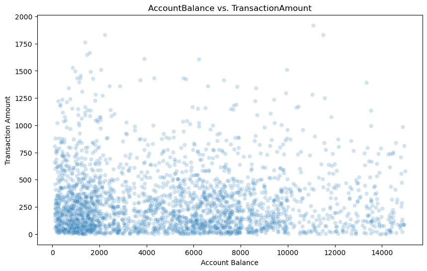

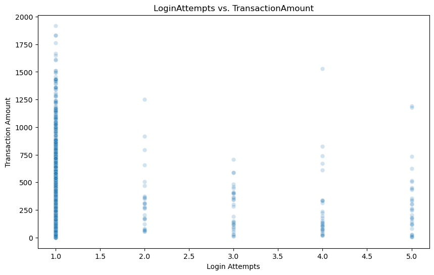

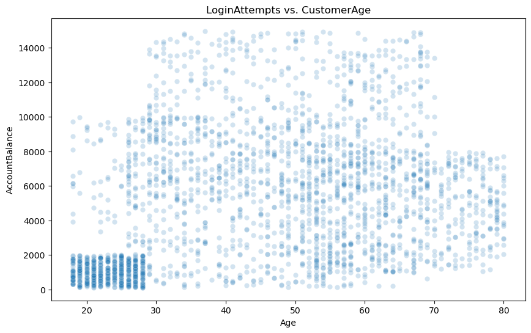

```python
# 1. Scatter Plot: AccountBalance vs. TransactionAmount
plt.figure(figsize=(10, 6))
sns.scatterplot(x='AccountBalance', y='TransactionAmount', data=df, alpha=0.2)
plt.title('AccountBalance vs. TransactionAmount')
plt.xlabel('Account Balance')
plt.ylabel('Transaction Amount')
plt.show()

# 2. Scatter Plot: LoginAttempts vs. TransactionAmount
plt.figure(figsize=(10, 6))
sns.scatterplot(x='LoginAttempts', y='TransactionAmount', data=df, alpha=0.2)
plt.title('LoginAttempts vs. TransactionAmount')
plt.xlabel('Login Attempts')
plt.ylabel('Transaction Amount')
plt.show()

# 3. Scatter Plot: LoginAttempts vs. CustomerAge
plt.figure(figsize=(10, 6))
sns.scatterplot(y='AccountBalance', x='CustomerAge', data=df, alpha=0.2)
plt.title('LoginAttempts vs. CustomerAge')
plt.xlabel('Age')
plt.ylabel('AccountBalance')
plt.show()
```

## Data Preprocessing

Encoding categorical vaules, Date conversion to DateTime, Scaling, Standardrizination

```python
# Encoding the categorical features
categorical_columns = ['TransactionType', 'Location', 'Channel', ]
le = LabelEncoder()

for col in categorical_columns:
    df[col] = le.fit_transform(df[col])

df[categorical_columns].head(10)
for col in categorical_columns:
    print(f"\nValue Counts for {col}:")
    print(df[col].value_counts())
```

```
Value Counts for TransactionType:
TransactionType
1    1944
0     568
Name: count, dtype: int64

Value Counts for Location:
Location
13    70
20    69
28    68
5     68
40    67
30    67
29    65
```

[output cut: 44 more lines]

Coverting the date colums datetime will allow us to do calcualtions on the data, pherhaps allowing us to use this in our model to spot anomolies.

```python
# Covert date cols to datetime

df['TransactionDate'] = pd.to_datetime(df['TransactionDate'])
df['PreviousTransactionDate'] = pd.to_datetime(df['PreviousTransactionDate'])

# Extract  thr datetime features
df['TransactionHour'] = df['TransactionDate'].dt.hour
df['TransactionDay'] = df['TransactionDate'].dt.day
df['TimeDiffSeconds'] = (df['TransactionDate'] - df['PreviousTransactionDate']).dt.total_seconds().abs()
```

```python
# summary of df
# Exclude 'TransactionType', 'Location', and 'Channel' from the describe output
df.describe().drop(columns=['TransactionType', 'Location', 'Channel',"PreviousTransactionDate","TransactionDate"])
```

|  | TransactionAmount | CustomerAge | TransactionDuration | LoginAttempts | AccountBalance | TransactionHour | TransactionDay | TimeDiffSeconds |
| --- | --- | --- | --- | --- | --- | --- | --- | --- |
| count | 2512.000000 | 2512.000000 | 2512.000000 | 2512.000000 | 2512.000000 | 2512.000000 | 2512.000000 | 2.512000e+03 |
| mean | 297.593778 | 44.673965 | 119.643312 | 1.124602 | 5114.302966 | 16.626194 | 15.827229 | 4.211863e+07 |
| min | 0.260000 | 18.000000 | 10.000000 | 1.000000 | 101.250000 | 16.000000 | 1.000000 | 2.657429e+07 |
| 25% | 81.885000 | 27.000000 | 63.000000 | 1.000000 | 1504.370000 | 16.000000 | 8.000000 | 3.408996e+07 |
| 50% | 211.140000 | 45.000000 | 112.500000 | 1.000000 | 4735.510000 | 16.000000 | 16.000000 | 4.195566e+07 |
| 75% | 414.527500 | 59.000000 | 161.000000 | 1.000000 | 7678.820000 | 17.000000 | 24.000000 | 5.016886e+07 |
| max | 1919.110000 | 80.000000 | 300.000000 | 5.000000 | 14977.990000 | 18.000000 | 31.000000 | 5.803267e+07 |
| std | 291.946243 | 17.792198 | 69.963757 | 0.602662 | 3900.942499 | 0.731059 | 8.761293 | 9.191205e+06 |

It is interesting to see the summary statitics for the numerical columns to compare to any potential anomolies detetcted by the model.

```python
# Standardize the numerical Data

scaler = StandardScaler()
numerical_columns = ['TransactionAmount', 'AccountBalance', 'TransactionDuration', 'LoginAttempts', 'TransactionHour', 'TransactionDay', 'TimeDiffSeconds']

df[numerical_columns] = scaler.fit_transform(df[numerical_columns])
```

```python
# summary of df
# Exclude 'TransactionType', 'Location', and 'Channel' from the describe output
df.describe().drop(columns=['TransactionType', 'Location', 'Channel',"PreviousTransactionDate","TransactionDate"])
```

|  | TransactionAmount | CustomerAge | TransactionDuration | LoginAttempts | AccountBalance | TransactionHour | TransactionDay | TimeDiffSeconds |
| --- | --- | --- | --- | --- | --- | --- | --- | --- |
| count | 2.512000e+03 | 2512.000000 | 2.512000e+03 | 2.512000e+03 | 2.512000e+03 | 2.512000e+03 | 2.512000e+03 | 2.512000e+03 |
| mean | -1.414297e-16 | 44.673965 | 7.637203e-17 | 1.527441e-16 | 4.985396e-17 | -6.463337e-16 | -7.195235e-17 | -2.326518e-16 |
| min | -1.018657e+00 | 18.000000 | -1.567456e+00 | -2.067936e-01 | -1.285344e+00 | -8.567285e-01 | -1.692693e+00 | -1.691556e+00 |
| 25% | -7.390118e-01 | 27.000000 | -8.097706e-01 | -2.067936e-01 | -9.255845e-01 | -8.567285e-01 | -8.935653e-01 | -8.736905e-01 |
| 50% | -2.961881e-01 | 45.000000 | -1.021205e-01 | -2.067936e-01 | -9.712227e-02 | -8.567285e-01 | 1.972370e-02 | -1.773444e-02 |
| 75% | 4.006114e-01 | 59.000000 | 5.912336e-01 | -2.067936e-01 | 6.575405e-01 | 5.114228e-01 | 9.330127e-01 | 8.760367e-01 |
| max | 5.555266e+00 | 80.000000 | 2.578372e+00 | 6.431745e+00 | 2.529043e+00 | 1.879574e+00 | 1.732141e+00 | 1.731787e+00 |
| std | 1.000199e+00 | 17.792198 | 1.000199e+00 | 1.000199e+00 | 1.000199e+00 | 1.000199e+00 | 1.000199e+00 | 1.000199e+00 |

## Models

### Isolation Forrest

The Isolation Model will include all numerical columns and the catergoical colems Location and Transaction type. it is expected that less than 1% of all bank tranactions are acutual fraud, I will use this a the contramination threshold to detect anomolies.

```python
# Train Isolation Forest

features = ['TransactionAmount', 'AccountBalance', 'TransactionDuration',
            'LoginAttempts', 'TransactionHour', 'TransactionDay', 'TimeDiffSeconds',
            "Location", "TransactionType","CustomerAge","Channel"]
iso_forest = IsolationForest(n_estimators=100, contamination=0.01, random_state=42)
df['anomaly'] = iso_forest.fit_predict(df[features])

# Display anomalies
anomalies = df[df['anomaly'] == -1]

print("Number of anomolies detected : ", len(anomalies))
anomalies.head(5)
```

```
Number of anomolies detected :  26
```

|  | TransactionID | AccountID | TransactionAmount | TransactionDate | TransactionType | Location | DeviceID | IP Address | MerchantID | Channel | CustomerAge | CustomerOccupation | TransactionDuration | LoginAttempts | AccountBalance | PreviousTransactionDate | TransactionHour | TransactionDay | TimeDiffSeconds | anomaly |
| --- | --- | --- | --- | --- | --- | --- | --- | --- | --- | --- | --- | --- | --- | --- | --- | --- | --- | --- | --- | --- |
| 274 | TX000275 | AC00454 | 3.010353 | 2023-12-20 16:08:02 | 0 | 18 | D000476 | 50.202.8.53 | M074 | 0 | 54 | Engineer | 0.777081 | 6.431745 | -1.228310 | 2024-11-04 08:11:44 | -0.856729 | 0.476368 | -1.577823 | -1 |
| 375 | TX000376 | AC00316 | 3.751253 | 2023-11-20 16:51:14 | 1 | 12 | D000113 | 63.67.150.226 | M013 | 1 | 41 | Doctor | 2.535484 | -0.206794 | 2.111035 | 2024-11-04 08:09:15 | -0.856729 | 0.476368 | -1.296057 | -1 |
| 394 | TX000395 | AC00326 | -0.997964 | 2023-12-14 18:52:54 | 1 | 8 | D000539 | 210.160.90.52 | M017 | 1 | 80 | Retired | 2.335341 | 6.431745 | 0.662376 | 2024-11-04 08:12:13 | 1.879574 | -0.208599 | -1.522484 | -1 |
| 454 | TX000455 | AC00264 | 1.074097 | 2023-10-18 18:32:31 | 1 | 11 | D000215 | 141.201.46.191 | M045 | 0 | 20 | Student | 2.321045 | 4.772110 | -1.075458 | 2024-11-04 08:11:12 | 1.879574 | 0.248046 | -0.986434 | -1 |
| 614 | TX000615 | AC00466 | 3.578961 | 2023-04-28 18:11:55 | 0 | 13 | D000643 | 28.149.72.129 | M032 | 1 | 21 | Student | 1.649135 | -0.206794 | -1.133355 | 2024-11-04 08:08:00 | 1.879574 | 1.389657 | 0.640254 | -1 |

```python
anomalies.info()

anomalies["TransactionType"].value_counts()
```

```
<class 'pandas.core.frame.DataFrame'>
Index: 26 entries, 274 to 2310
Data columns (total 20 columns):
 #   Column                   Non-Null Count  Dtype
---  ------                   --------------  -----
 0   TransactionID            26 non-null     object
 1   AccountID                26 non-null     object
 2   TransactionAmount        26 non-null     float64
 3   TransactionDate          26 non-null     datetime64[ns]
 4   TransactionType          26 non-null     int32
 5   Location                 26 non-null     int32
 6   DeviceID                 26 non-null     object
 7   IP Address               26 non-null     object
 8   MerchantID               26 non-null     object
 9   Channel                  26 non-null     int32
 10  CustomerAge              26 non-null     int64
 11  CustomerOccupation       26 non-null     object
 12  TransactionDuration      26 non-null     float64
 13  LoginAttempts            26 non-null     float64
 14  AccountBalance           26 non-null     float64
 15  PreviousTransactionDate  26 non-null     datetime64[ns]
 16  TransactionHour          26 non-null     float64
 17  TransactionDay           26 non-null     float64
 18  TimeDiffSeconds          26 non-null     float64
 19  anomaly                  26 non-null     int32
dtypes: datetime64[ns](2), float64(7), int32(4), int64(1), object(6)
memory usage: 3.9+ KB
```

```
TransactionType
0    16
1    10
Name: count, dtype: int64
```

```python
anomalies["Channel"].value_counts()
```

```
Channel
0    9
2    9
1    8
Name: count, dtype: int64
```

Lets see where in our tractional data the anomolies show up

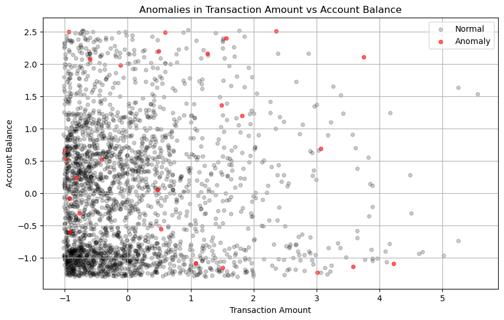

```python
# Scatter plot for Transaction Amount vs Account Balance
plt.figure(figsize=(10, 6))
plt.figure(figsize=(10, 6))

# Plot normal transactions (grey)
normal = df[df['anomaly'] == 1]
plt.scatter(normal['TransactionAmount'], normal['AccountBalance'],
            color='black', label='Normal', alpha=0.2, s=20)

# Plot anomalies (red)
anomalies = df[df['anomaly'] == -1]
plt.scatter(anomalies['TransactionAmount'], anomalies['AccountBalance'],
            color='red', label='Anomaly', alpha=0.6, s=20)

# Add plot labels and legend
plt.xlabel('Transaction Amount')
plt.ylabel('Account Balance')
plt.title('Anomalies in Transaction Amount vs Account Balance')
plt.legend()
plt.grid(True)
```

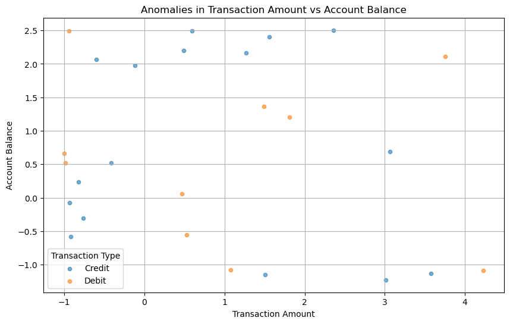

```python
plt.figure(figsize=(6, 4))

transaction_type_labels = {0: 'Credit', 1: 'Debit'}

# Create a scatter plot for each unique TransactionType
plt.figure(figsize=(10, 6))

for t_type in anomalies['TransactionType'].unique():
    subset = anomalies[anomalies['TransactionType'] == t_type]
    plt.scatter(subset['TransactionAmount'], subset['AccountBalance'],
                label=transaction_type_labels.get(t_type, f'Type {t_type}'),
                alpha=0.6, s=20)

# Add plot labels and legend
plt.xlabel('Transaction Amount')
plt.ylabel('Account Balance')
plt.title('Anomalies in Transaction Amount vs Account Balance')
plt.legend(title='Transaction Type')
plt.grid(True)

# Show the plot
plt.show()
```

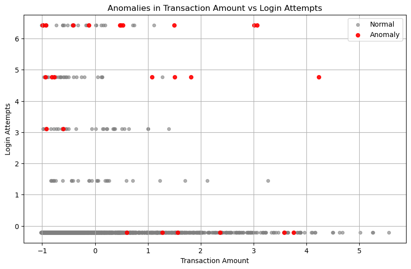

```python
plt.figure(figsize=(10, 6))

# Plot normal transactions (grey)
plt.scatter(normal['TransactionAmount'], normal['LoginAttempts'], color='grey', label='Normal', alpha=0.6, s=20)

# Plot anomalies (red)
plt.scatter(anomalies['TransactionAmount'], anomalies['LoginAttempts'], color='red', label='Anomaly', alpha=0.9, s=30)

plt.xlabel('Transaction Amount')
plt.ylabel('Login Attempts')
plt.title('Anomalies in Transaction Amount vs Login Attempts')
plt.legend()
plt.grid(True)
plt.show()
```

The above shows the scaled scatterplot of Account Balance and Tranaction Amount the red points are onservations the isolation forrest model detetected as critical outliers. But we still dont know why lets dive a bit deeper. To do this we can use the Shap library to visualize which features are having on the model. The Second figure highlights the same anomolies in plot with login attempts vs tranaction amount.

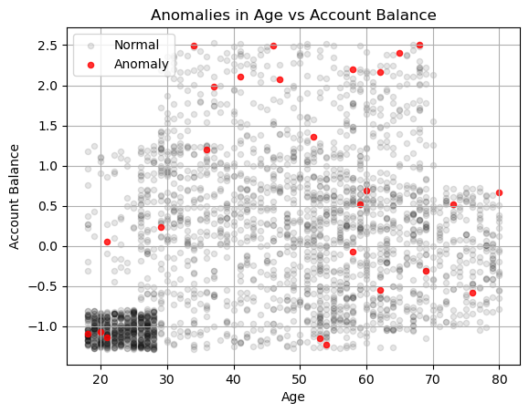

```python
normal = df[df['anomaly'] == 1]
plt.scatter(normal['CustomerAge'], normal['AccountBalance'],
            color='black', label='Normal', alpha=0.1, s=20)

# Plot anomalies (red)
anomalies = df[df['anomaly'] == -1]
plt.scatter(anomalies['CustomerAge'], anomalies['AccountBalance'],
            color='red', label='Anomaly', alpha=0.8, s=20)

# Add plot labels and legend
plt.xlabel('Age')
plt.ylabel('Account Balance')
plt.title('Anomalies in Age vs Account Balance')
plt.legend()
plt.grid(True)
```

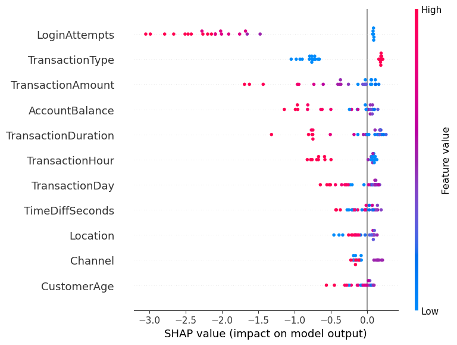

```python
import shap
# Create SHAP explainer
explainer = shap.Explainer(iso_forest)

# Calculate SHAP values for the sample data
shap_values = explainer(anomalies[features])

# Visualize SHAP values for the sample data
shap.summary_plot(shap_values, anomalies[features])
```

The Shap plot shows us the importance of our features when looking into detetecting an anomoly, the model has highlighted login attempts, Transaction type, and transaction amount as the most significant features in detetecting an outlier. With a contamination of 0.01. We can explore differences in the anomolies detetected agaisnt our original data to make an informed decision about evluating the model. Because the model is unserpervised our original dataset was unlabled and therefore can't compute a traditional validation process.

```python
# Inverse transform the numerical columns back to original scales
anomalies_original_scale = anomalies.copy()
anomalies_original_scale[numerical_columns] = scaler.inverse_transform(anomalies[numerical_columns])

# Display anomalies with original scales
print(anomalies_original_scale[numerical_columns].head(5))
anomalies_original_scale.describe().drop(columns=['TransactionType', 'Location', 'Channel',"PreviousTransactionDate","TransactionDate"])
```

```
     TransactionAmount  AccountBalance  TransactionDuration  LoginAttempts  \
274            1176.28          323.69                174.0            5.0
375            1392.54        13347.69                297.0            1.0
394               6.30         7697.68                283.0            5.0
454             611.11          919.84                282.0            4.0
614            1342.25          694.03                235.0            1.0

     TransactionHour  TransactionDay  TimeDiffSeconds
274             16.0            20.0       27619422.0
375             16.0            20.0       30208681.0
394             18.0            14.0       28127959.0
454             18.0            18.0       33053921.0
614             18.0            28.0       48002165.0
```

|  | TransactionAmount | CustomerAge | TransactionDuration | LoginAttempts | AccountBalance | TransactionHour | TransactionDay | TimeDiffSeconds | anomaly |
| --- | --- | --- | --- | --- | --- | --- | --- | --- | --- |
| count | 26.000000 | 26.000000 | 26.000000 | 26.000000 | 26.000000 | 26.000000 | 26.000000 | 2.600000e+01 | 26.0 |
| mean | 559.214615 | 49.961538 | 162.884615 | 3.653846 | 7886.535769 | 16.884615 | 19.423077 | 4.172437e+07 | -1.0 |
| min | 6.300000 | 18.000000 | 43.000000 | 1.000000 | 323.690000 | 16.000000 | 3.000000 | 2.753207e+07 | -1.0 |
| 25% | 86.295000 | 36.250000 | 94.000000 | 3.000000 | 3202.495000 | 16.000000 | 14.000000 | 3.216801e+07 | -1.0 |
| 50% | 461.595000 | 53.500000 | 144.500000 | 4.000000 | 7426.360000 | 17.000000 | 20.000000 | 4.005728e+07 | -1.0 |
| 75% | 808.527500 | 62.000000 | 248.500000 | 5.000000 | 13307.115000 | 18.000000 | 27.750000 | 5.187108e+07 | -1.0 |
| max | 1531.310000 | 80.000000 | 297.000000 | 5.000000 | 14881.770000 | 18.000000 | 31.000000 | 5.794437e+07 | -1.0 |
| std | 482.553683 | 18.346620 | 83.422935 | 1.598557 | 5266.342458 | 0.908930 | 9.011873 | 1.080460e+07 | 0.0 |

From the above output we can see that model's anomolies detection has produced very different summary stats then we saw for the entirety of the data set.

```
                I will plot the differences and print a  data frame to inspect.
```

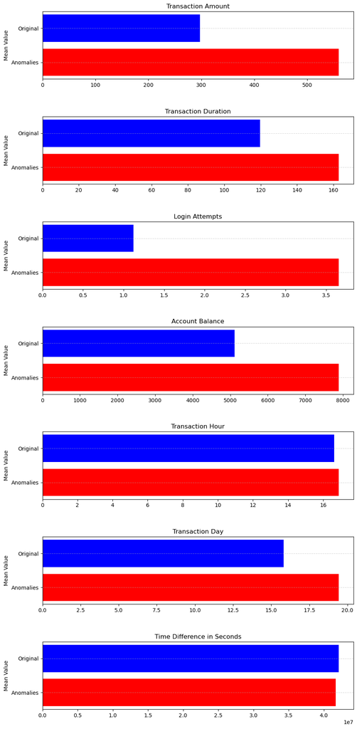

|  | Metric | Percent Change in Mean |
| --- | --- | --- |
| 0 | Transaction Amount | 87.914244 |
| 1 | Transaction Duration | 36.145102 |
| 2 | Login Attempts | 225.000000 |
| 3 | Account Balance | 54.205561 |
| 4 | Transaction Hour | 1.551786 |
| 5 | Transaction Day | 22.720667 |
| 6 | Time Difference in Seconds | -0.936070 |

```python
anomalies_means={"Transaction Amount":559.214, "Transaction Duration":162.884, "Login Attempts":3.653,"Account Balance":7886.535,"Transaction Hour": 16.884,"Transaction Day": 19.423, "Time Difference in Seconds":4.172437e+07}
original_means={"Transaction Amount":297.59, "Transaction Duration":119.64, "Login Attempts":1.124,"Account Balance":5114.30,"Transaction Hour": 16.626,"Transaction Day": 15.827, "Time Difference in Seconds":4.211863e+07}

percentage_difference = {
    key: ((anomalies_means[key] - original_means[key]) / original_means[key]) * 100
    for key in anomalies_means
}

fig, axes = plt.subplots(nrows=len(anomalies_means), ncols=1, figsize=(10, 20))
fig.tight_layout(pad=5.0)

# Iterate over each metric and plot
for i, metric in enumerate(anomalies_means.keys()):
    axes[i].barh(['Anomalies', 'Original'], [anomalies_means[metric], original_means[metric]], color=['red', 'blue'])
    axes[i].set_title(f'{metric}')
    axes[i].set_ylabel('Mean Value')
    axes[i].grid(axis='y', linestyle='--', alpha=0.5)

# Show the plot
plt.show()

# Display the plot
plt.show()
# Display the percentage differences
df_percentage_diff = pd.DataFrame(list(percentage_difference.items()), columns=["Metric", "Percent Change in Mean"])

# Display the DataFrame
df_percentage_diff
```

Percent Change Analysis

Transaction Amount: Anomalies have a significantly higher transaction amount (+87.91%). This suggests that unusually large transactions are more likely to be flagged as anomalies.

Login Attempts: Anomalies show a 225% increase in login attempts. This is a strong indicator of potential fraud (e.g., repeated attempts to access accounts).

Transaction Duration: Anomalies take longer to process (+36.15%), which could indicate more complex or suspicious transactions.

Account Balance: Anomalies are associated with higher account balances (+54.21%). This could suggest high-value accounts being targeted.

Transaction Hour and Day: Although the differences are smaller, anomalies tend to happen at slightly different hours and on different days compared to normal transactions.

Time Difference in Seconds: The time between transactions for anomalies is slightly shorter (-0.94%), which indicates this feature is not a stong indicator of afor anomaly detection.

# Conclusions

Conclusion The goal of this project was to find unusual transactions (anomalies) in bank data using the Isolation Forest algorithm and figure out which features made these transactions stand out. Since the data didn’t have labels, we used unsupervised learning methods and tools to understand the results.

Data Preparation:

We encoded categories like TransactionType, Location, and Channel. We standardized numerical features like TransactionAmount, AccountBalance, and LoginAttempts. We created time-based features, such as TransactionHour and TransactionDay.

Anomaly Detection:

We ran the Isolation Forest with a contamination rate of 0.01, based on the idea that less than 1% of transactions are typically fraud. The model flagged 26 transactions as anomalies.

Understanding the Model:

We used SHAP (SHapley Additive exPlanations) to see which features the model relied on most.

The key features that led to anomalies were:

Transaction Amount Login Attempts Account Balance Transaction Type

Comparing Means:

We compared the average values of numerical features between anomalies and normal transactions. This showed that anomalies often had higher transaction amounts, more login attempts, and higher account balances.

We also compared the value_counts od tranaction types, while 0ver 70% all tranctions were debit transactions only 38% pf the anomalies where debit type indicating the suspcisous activity might me more prevalent on credit tranactions.

Answering the Research Question:

We wanted to know how to detect anomalies in bank transactions with no labels and what features are most important. The Isolation Forest helped us find these anomalies, and SHAP showed us which features mattered most. By combining the model's results with our understanding of the data, we got a clearer picture of what makes these transactions unusual.

Future Studies To improve anomaly detection in future studies, adding features like Device ID and IP address could be valuable. For example:

ATM Locations: ATMs are known hotspots for suspicious transactions. Including Device IDs for ATMs can help flag anomalies more accurately. IP Address Tracking: If an account shows multiple login attempts from an unfamiliar IP address, this could indicate potential fraud or unauthorized access. These additional features can enhance the model’s ability to detect anomalies and provide more context for understanding suspicious activities.

This project shows that unsupervised learning can do a good job of finding outliers, even when we don’t have labeled data. Using tools like SHAP helps explain the model's decisions, and adding domain knowledge makes the results meaningful.